# Data Visualization Project 1: Titanic Passenger Data Analysis

**Bryan Amaefule, Kevin Lee, Shannon Lu**

First we load the required packages from .TestProfile

```r
source("../02 Visualizations/.TestProfile", echo=TRUE)
```

```
##
## > require("jsonlite")
##
## > require("RCurl")
##
## > require("reshape2")
##
## > require("ggplot2")
```

The following is data from the first six passengers on the Titanic, found in the database, followed by more descriptive plots to further show details.

```r
db <- data.frame(fromJSON(getURL(URLencode('129.152.144.84:5001/rest/native/?query="select * from titanic"'),httpheader=c(DB='jdbc:oracle:thin:@129.152.144.84:1521/PDBF15DV.usuniversi01134.oraclecloud.internal', USER='cs329e_ba7433', PASS='orcl_ba7433', MODE='native_mode', MODEL='model', returnDimensions = 'False', returnFor = 'JSON'), verbose = TRUE), ))

head(db)
```

```
##   PASSENGERID SURVIVED PCLASS                             NAME    SEX  AGE
## 1         104        0      3       Johansson, Mr. Gustaf Joel   male   33
## 2         105        0      3   Gustafsson, Mr. Anders Vilhelm   male   37
## 3         106        0      3            Mionoff, Mr. Stoytcho   male   28
## 4         107        1      3 Salkjelsvik, Miss. Anna Kristine female   21
## 5         108        1      3           Moss, Mr. Albert Johan   male null
## 6         109        0      3                  Rekic, Mr. Tido   male   38
##   SIBSP PARCH  TICKET             FARE CABIN EMBARKED
## 1     0     0    7540 8.65419960021973  null        S
## 2     2     0 3101276 7.92500019073486  null        S
## 3     0     0  349207 7.89580011367798  null        S
## 4     0     0  343120 7.65000009536743  null        S
## 5     0     0  312991 7.77500009536743  null        S
## 6     0     0  349249 7.89580011367798  null        S
```

The first ggplot program uses a generic “select * from titanic” SQL query. We plot the fare paid by each passenger (y-axis) against their age (x-axis). Both fare and age are plotted as continuous variables. Each passengers sex is color-coded according to the legend on the right. Passengers whose sex was not reported are depicted by null.

```
##
## > plot1 <- data.frame(fromJSON(getURL(URLencode("129.152.144.84:5001/rest/native/?query=\"select * from titanic\""),
## +     httpheader = c(DB = "jdbc: ..." ... [TRUNCATED]
##
## > ggplot() + coord_cartesian() + scale_x_continuous() +
## +     scale_y_continuous() + labs(title = "Titanic") + labs(x = "Age",
## +     y = paste("Fare ..." ... [TRUNCATED]
```

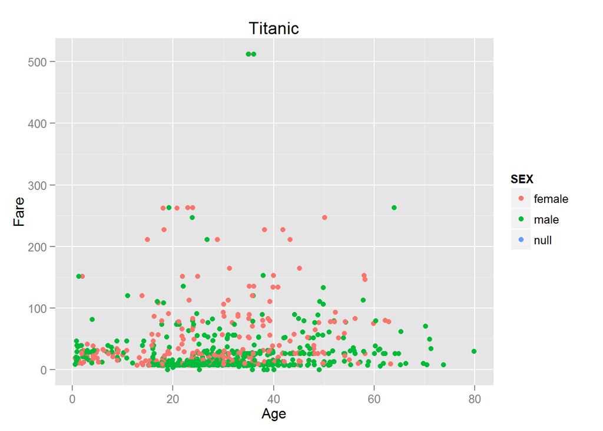

```r
source("../02 Visualizations/Plot1.R", echo=TRUE)
```

The second plot follows the same guidlines as the first plot, however, we now only account for passengers whose sex has been reported. Using the SQL query “select * from titanic where sex is not null” filters out passengers whose sex were not known.

```
##
## > plot2 <- data.frame(fromJSON(getURL(URLencode("129.152.144.84:5001/rest/native/?query=\"select * from titanic where sex is not null\""),
## +     http .... [TRUNCATED]
##
## > ggplot() + coord_cartesian() + scale_x_continuous() +
## +     scale_y_continuous() + labs(title = "Titanic") + labs(x = "Age",
## +     y = paste("Fare ..." ... [TRUNCATED]
```

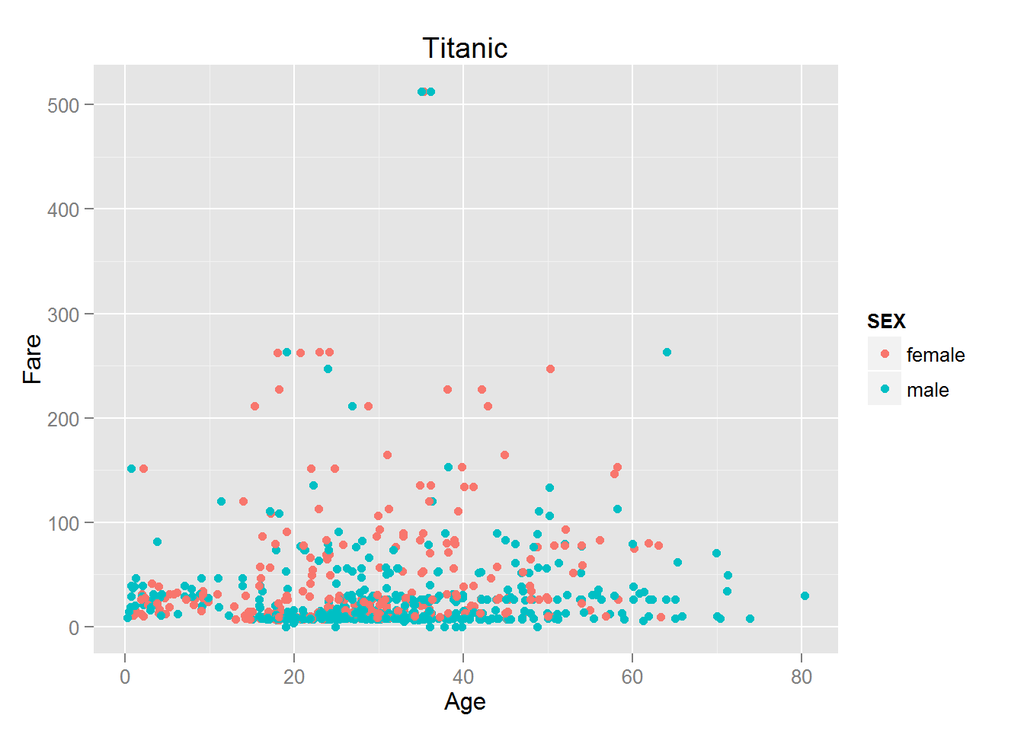

```r
source("../02 Visualizations/Plot2.R", echo=TRUE)
```

From the first two plots, it is apparent that most passengers paid fares below 100, some paid up to 200-300, and an exceptional few paid fares over 500.

The third plot shows the relationships between the fare paid by each passenger, their sex, and whether or not they survived. Fare is left as a continuous value on the y-axis, while sex is set as a discrete value on the x-axis. Passengers are color-coded according to whether they survived the tragedy or not. A 0 (red dot) means that this passenger did not survive, while a 1 (blue dot) indicates that this passenger did survive.

```
##
## > plot3 <- data.frame(fromJSON(getURL(URLencode("129.152.144.84:5001/rest/native/?query=\"select * from titanic where sex is not null\""),
## +     http .... [TRUNCATED]
##
## > ggplot() + coord_cartesian() + scale_x_discrete() +
## +     scale_y_continuous() + labs(title = "Titanic") + labs(x = "SURVIVED",
## +     y = paste("F ..." ... [TRUNCATED]
```

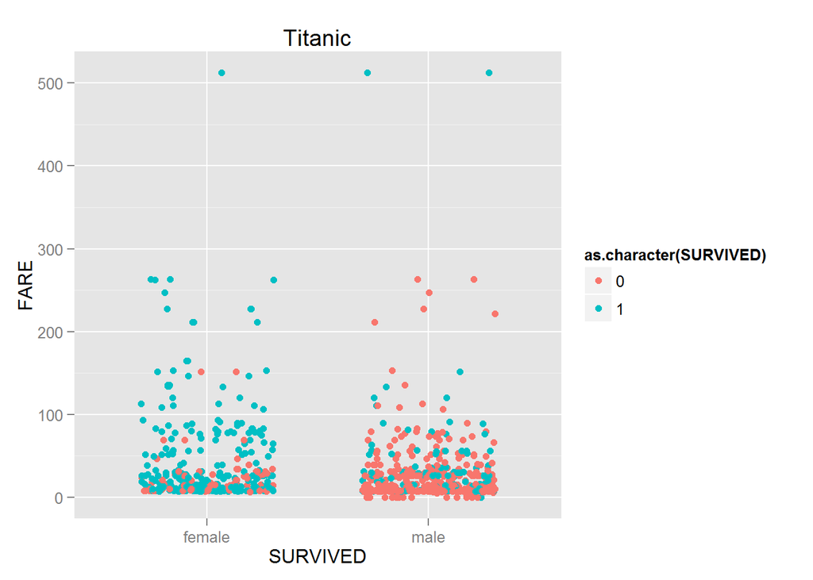

```r
source("../02 Visualizations/Plot3.R", echo=TRUE)
```

The plot indicates that female passengers survived at a higher rate than male passengers did, which probably makes sense, given the common idea of putting women and children at a higher priority.

The fourth plot keeps the same axis variables as the previous one, however, we now use a facet grid to group passengers by their class and whether or not they survived. Passengers sex is color-coded according to the legend.

```
##
## > plot4 <- data.frame(fromJSON(getURL(URLencode("129.152.144.84:5001/rest/native/?query=\"select * from titanic where sex is not null AND pclass is no .... [TRUNCATED]
##
## > ggplot() + coord_cartesian() + scale_x_discrete() +
## +     scale_y_continuous() + facet_grid(PCLASS ~ SURVIVED, labeller = label_both) +
## +     labs .... [TRUNCATED]
```

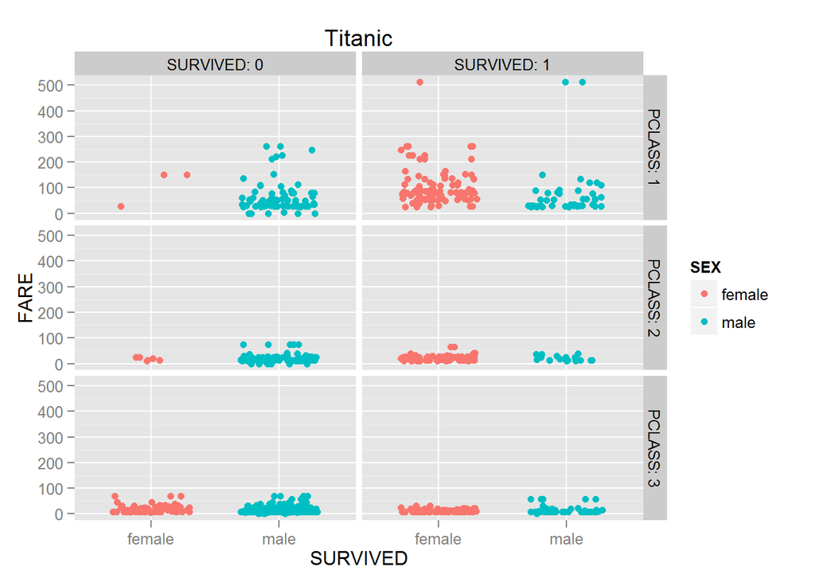

```r
source("../02 Visualizations/Plot4.R", echo=TRUE)
```

By applying the SQL query ‘select * from titanic where sex is not null AND age <= 10’ to the same facet grid from the plot above we are able to see the survival rates of children under 10 years of age according to their class.

```
##
## > plot5 <- data.frame(fromJSON(getURL(URLencode("129.152.144.84:5001/rest/native/?query=\"select * from titanic where sex is not null AND age <= 10\"" .... [TRUNCATED]
##
## > ggplot() + coord_cartesian() + scale_x_discrete() +
## +     scale_y_continuous() + facet_grid(PCLASS ~ SURVIVED, labeller = label_both) +
## +     labs .... [TRUNCATED]
```

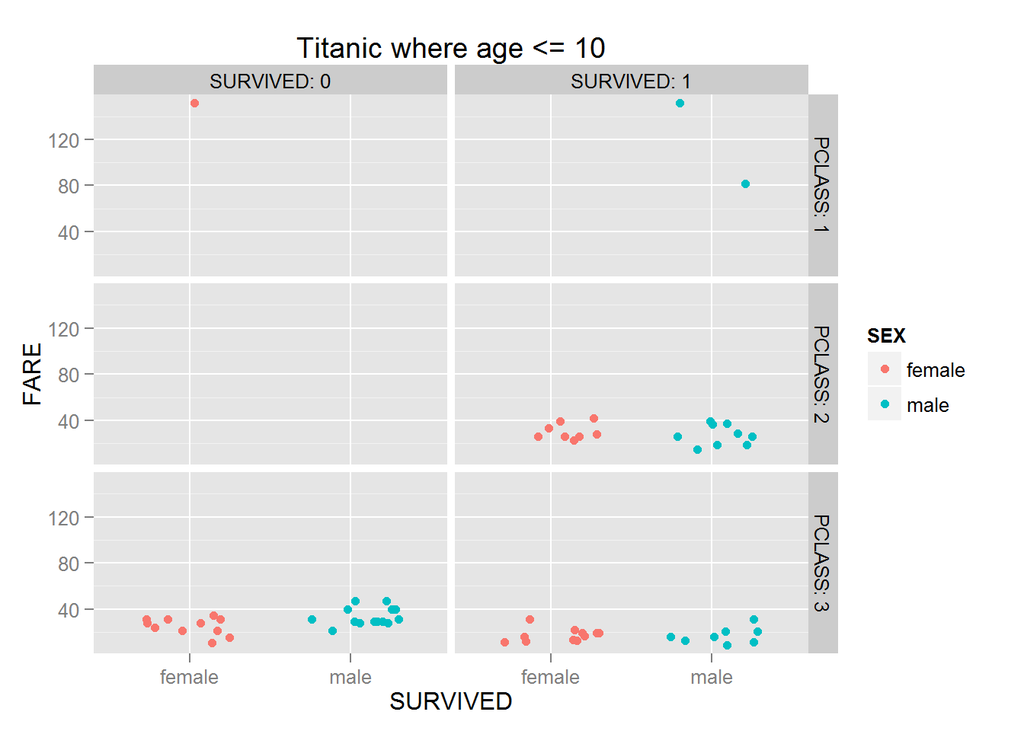

```r
source("../02 Visualizations/Plot5.R", echo=TRUE)
```

The 6th plot was an idea we came up with ourselves. “Women and children first” is common saying in regards to maritime disasters. But where did passengers on the Titanic prioritize the elderly? In antitheis to the 5th plot, the plot below shows the survival rate of senior citizens (passengers 60 years or older). The axes and facet grid remain the same from the previous plot, while the SQL query was changed to ‘select * from titanic where sex is not null AND age >= 60’.

```
##
## > plot6 <- data.frame(fromJSON(getURL(URLencode("129.152.144.84:5001/rest/native/?query=\"select * from titanic where sex is not null AND age >= 60\"" .... [TRUNCATED]
##
## > ggplot() + coord_cartesian() + scale_x_discrete() +
## +     scale_y_continuous() + facet_grid(PCLASS ~ SURVIVED, labeller = label_both) +
## +     labs .... [TRUNCATED]
```

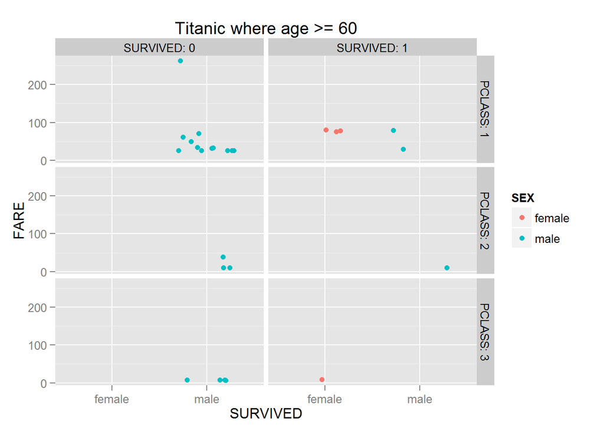

```r
source("../02 Visualizations/Plot6.R", echo=TRUE)
```

```r
summary(db)
```

[output not shown]